# Optimal Treatment Analysis

## Outcome Variable

**Outcome Variable:** ever_wasted

## Predictor Variables

**Intervention Variable:** brthmon

**Adjustment Set:**

unadjusted

## Stratifying Variables

The analysis was stratified on these variable(s):

- agecat
- studyid
- country

## Data Summary

| agecat | studyid | country | brthmon | ever_wasted | n_cell | n |
| --- | --- | --- | --- | --- | --- | --- |
| 0-24 months | ki0047075b-MAL-ED | BANGLADESH | 1 | 0 | 14 | 263 |
| 0-24 months | ki0047075b-MAL-ED | BANGLADESH | 1 | 1 | 7 | 263 |
| 0-24 months | ki0047075b-MAL-ED | BANGLADESH | 2 | 0 | 16 | 263 |
| 0-24 months | ki0047075b-MAL-ED | BANGLADESH | 2 | 1 | 9 | 263 |
| 0-24 months | ki0047075b-MAL-ED | BANGLADESH | 3 | 0 | 9 | 263 |
| 0-24 months | ki0047075b-MAL-ED | BANGLADESH | 3 | 1 | 15 | 263 |
| 0-24 months | ki0047075b-MAL-ED | BANGLADESH | 4 | 0 | 15 | 263 |
| 0-24 months | ki0047075b-MAL-ED | BANGLADESH | 4 | 1 | 7 | 263 |
| 0-24 months | ki0047075b-MAL-ED | BANGLADESH | 5 | 0 | 15 | 263 |
| 0-24 months | ki0047075b-MAL-ED | BANGLADESH | 5 | 1 | 7 | 263 |
| 0-24 months | ki0047075b-MAL-ED | BANGLADESH | 6 | 0 | 9 | 263 |
| 0-24 months | ki0047075b-MAL-ED | BANGLADESH | 6 | 1 | 2 | 263 |
| 0-24 months | ki0047075b-MAL-ED | BANGLADESH | 7 | 0 | 12 | 263 |
| 0-24 months | ki0047075b-MAL-ED | BANGLADESH | 7 | 1 | 8 | 263 |
| 0-24 months | ki0047075b-MAL-ED | BANGLADESH | 8 | 0 | 22 | 263 |
| 0-24 months | ki0047075b-MAL-ED | BANGLADESH | 8 | 1 | 4 | 263 |
| 0-24 months | ki0047075b-MAL-ED | BANGLADESH | 9 | 0 | 10 | 263 |
| 0-24 months | ki0047075b-MAL-ED | BANGLADESH | 9 | 1 | 13 | 263 |
| 0-24 months | ki0047075b-MAL-ED | BANGLADESH | 10 | 0 | 18 | 263 |
| 0-24 months | ki0047075b-MAL-ED | BANGLADESH | 10 | 1 | 6 | 263 |
| 0-24 months | ki0047075b-MAL-ED | BANGLADESH | 11 | 0 | 14 | 263 |
| 0-24 months | ki0047075b-MAL-ED | BANGLADESH | 11 | 1 | 3 | 263 |
| 0-24 months | ki0047075b-MAL-ED | BANGLADESH | 12 | 0 | 22 | 263 |
| 0-24 months | ki0047075b-MAL-ED | BANGLADESH | 12 | 1 | 6 | 263 |
| 0-24 months | ki0047075b-MAL-ED | BRAZIL | 1 | 0 | 13 | 233 |
| 0-24 months | ki0047075b-MAL-ED | BRAZIL | 1 | 1 | 2 | 233 |
| 0-24 months | ki0047075b-MAL-ED | BRAZIL | 2 | 0 | 22 | 233 |
| 0-24 months | ki0047075b-MAL-ED | BRAZIL | 2 | 1 | 3 | 233 |
| 0-24 months | ki0047075b-MAL-ED | BRAZIL | 3 | 0 | 19 | 233 |
| 0-24 months | ki0047075b-MAL-ED | BRAZIL | 3 | 1 | 1 | 233 |

[output cut: 2034 more lines]

The following strata were considered:

- agecat: 0-24 months, studyid: ki0047075b-MAL-ED, country: BANGLADESH
- agecat: 0-24 months, studyid: ki0047075b-MAL-ED, country: BRAZIL
- agecat: 0-24 months, studyid: ki0047075b-MAL-ED, country: INDIA
- agecat: 0-24 months, studyid: ki0047075b-MAL-ED, country: NEPAL
- agecat: 0-24 months, studyid: ki0047075b-MAL-ED, country: PERU
- agecat: 0-24 months, studyid: ki0047075b-MAL-ED, country: SOUTH AFRICA
- agecat: 0-24 months, studyid: ki0047075b-MAL-ED, country: TANZANIA, UNITED REPUBLIC OF
- agecat: 0-24 months, studyid: ki1000108-CMC-V-BCS-2002, country: INDIA
- agecat: 0-24 months, studyid: ki1000108-IRC, country: INDIA
- agecat: 0-24 months, studyid: ki1000109-EE, country: PAKISTAN
- agecat: 0-24 months, studyid: ki1000109-ResPak, country: PAKISTAN
- agecat: 0-24 months, studyid: ki1000304b-SAS-CompFeed, country: INDIA
- agecat: 0-24 months, studyid: ki1000304b-SAS-FoodSuppl, country: INDIA
- agecat: 0-24 months, studyid: ki1017093-NIH-Birth, country: BANGLADESH
- agecat: 0-24 months, studyid: ki1066203-TanzaniaChild2, country: TANZANIA, UNITED REPUBLIC OF
- agecat: 0-24 months, studyid: ki1101329-Keneba, country: GAMBIA
- agecat: 0-24 months, studyid: ki1112895-Guatemala BSC, country: GUATEMALA
- agecat: 0-24 months, studyid: ki1112895-iLiNS-Zinc, country: BURKINA FASO
- agecat: 0-24 months, studyid: ki1113344-GMS-Nepal, country: NEPAL
- agecat: 0-24 months, studyid: ki1114097-CMIN, country: BANGLADESH
- agecat: 0-24 months, studyid: ki1114097-CMIN, country: BRAZIL
- agecat: 0-24 months, studyid: ki1114097-CMIN, country: GUINEA-BISSAU
- agecat: 0-24 months, studyid: ki1114097-CMIN, country: PERU
- agecat: 0-24 months, studyid: ki1114097-CONTENT, country: PERU
- agecat: 0-24 months, studyid: ki1119695-PROBIT, country: BELARUS
- agecat: 0-24 months, studyid: ki1126311-ZVITAMBO, country: ZIMBABWE
- agecat: 0-24 months, studyid: ki1148112-LCNI-5, country: MALAWI
- agecat: 0-24 months, studyid: kiGH5241-JiVitA-3, country: BANGLADESH
- agecat: 0-24 months, studyid: kiGH5241-JiVitA-4, country: BANGLADESH
- agecat: 0-6 months, studyid: ki0047075b-MAL-ED, country: BANGLADESH
- agecat: 0-6 months, studyid: ki0047075b-MAL-ED, country: BRAZIL
- agecat: 0-6 months, studyid: ki0047075b-MAL-ED, country: INDIA
- agecat: 0-6 months, studyid: ki0047075b-MAL-ED, country: NEPAL
- agecat: 0-6 months, studyid: ki0047075b-MAL-ED, country: PERU
- agecat: 0-6 months, studyid: ki0047075b-MAL-ED, country: SOUTH AFRICA
- agecat: 0-6 months, studyid: ki0047075b-MAL-ED, country: TANZANIA, UNITED REPUBLIC OF
- agecat: 0-6 months, studyid: ki1000108-CMC-V-BCS-2002, country: INDIA
- agecat: 0-6 months, studyid: ki1000108-IRC, country: INDIA
- agecat: 0-6 months, studyid: ki1000109-EE, country: PAKISTAN
- agecat: 0-6 months, studyid: ki1000109-ResPak, country: PAKISTAN
- agecat: 0-6 months, studyid: ki1000304b-SAS-CompFeed, country: INDIA
- agecat: 0-6 months, studyid: ki1000304b-SAS-FoodSuppl, country: INDIA
- agecat: 0-6 months, studyid: ki1017093-NIH-Birth, country: BANGLADESH
- agecat: 0-6 months, studyid: ki1066203-TanzaniaChild2, country: TANZANIA, UNITED REPUBLIC OF
- agecat: 0-6 months, studyid: ki1101329-Keneba, country: GAMBIA
- agecat: 0-6 months, studyid: ki1112895-Guatemala BSC, country: GUATEMALA
- agecat: 0-6 months, studyid: ki1113344-GMS-Nepal, country: NEPAL
- agecat: 0-6 months, studyid: ki1114097-CMIN, country: BANGLADESH
- agecat: 0-6 months, studyid: ki1114097-CMIN, country: BRAZIL
- agecat: 0-6 months, studyid: ki1114097-CMIN, country: GUINEA-BISSAU
- agecat: 0-6 months, studyid: ki1114097-CMIN, country: PERU
- agecat: 0-6 months, studyid: ki1114097-CONTENT, country: PERU
- agecat: 0-6 months, studyid: ki1119695-PROBIT, country: BELARUS
- agecat: 0-6 months, studyid: ki1126311-ZVITAMBO, country: ZIMBABWE
- agecat: 0-6 months, studyid: ki1148112-LCNI-5, country: MALAWI
- agecat: 0-6 months, studyid: kiGH5241-JiVitA-3, country: BANGLADESH
- agecat: 0-6 months, studyid: kiGH5241-JiVitA-4, country: BANGLADESH
- agecat: 6-24 months, studyid: ki0047075b-MAL-ED, country: BANGLADESH
- agecat: 6-24 months, studyid: ki0047075b-MAL-ED, country: BRAZIL
- agecat: 6-24 months, studyid: ki0047075b-MAL-ED, country: INDIA
- agecat: 6-24 months, studyid: ki0047075b-MAL-ED, country: NEPAL
- agecat: 6-24 months, studyid: ki0047075b-MAL-ED, country: PERU
- agecat: 6-24 months, studyid: ki0047075b-MAL-ED, country: SOUTH AFRICA
- agecat: 6-24 months, studyid: ki0047075b-MAL-ED, country: TANZANIA, UNITED REPUBLIC OF
- agecat: 6-24 months, studyid: ki1000108-CMC-V-BCS-2002, country: INDIA
- agecat: 6-24 months, studyid: ki1000108-IRC, country: INDIA
- agecat: 6-24 months, studyid: ki1000109-EE, country: PAKISTAN
- agecat: 6-24 months, studyid: ki1000109-ResPak, country: PAKISTAN
- agecat: 6-24 months, studyid: ki1000304b-SAS-CompFeed, country: INDIA
- agecat: 6-24 months, studyid: ki1000304b-SAS-FoodSuppl, country: INDIA
- agecat: 6-24 months, studyid: ki1017093-NIH-Birth, country: BANGLADESH
- agecat: 6-24 months, studyid: ki1066203-TanzaniaChild2, country: TANZANIA, UNITED REPUBLIC OF
- agecat: 6-24 months, studyid: ki1101329-Keneba, country: GAMBIA
- agecat: 6-24 months, studyid: ki1112895-Guatemala BSC, country: GUATEMALA
- agecat: 6-24 months, studyid: ki1112895-iLiNS-Zinc, country: BURKINA FASO
- agecat: 6-24 months, studyid: ki1113344-GMS-Nepal, country: NEPAL
- agecat: 6-24 months, studyid: ki1114097-CMIN, country: BANGLADESH
- agecat: 6-24 months, studyid: ki1114097-CMIN, country: BRAZIL
- agecat: 6-24 months, studyid: ki1114097-CMIN, country: GUINEA-BISSAU
- agecat: 6-24 months, studyid: ki1114097-CMIN, country: PERU
- agecat: 6-24 months, studyid: ki1114097-CONTENT, country: PERU
- agecat: 6-24 months, studyid: ki1119695-PROBIT, country: BELARUS
- agecat: 6-24 months, studyid: ki1126311-ZVITAMBO, country: ZIMBABWE
- agecat: 6-24 months, studyid: ki1148112-LCNI-5, country: MALAWI
- agecat: 6-24 months, studyid: kiGH5241-JiVitA-3, country: BANGLADESH
- agecat: 6-24 months, studyid: kiGH5241-JiVitA-4, country: BANGLADESH

### Dropped Strata

Some strata were dropped due to rare outcomes:

- agecat: 0-24 months, studyid: ki0047075b-MAL-ED, country: BANGLADESH
- agecat: 0-24 months, studyid: ki0047075b-MAL-ED, country: BRAZIL
- agecat: 0-24 months, studyid: ki0047075b-MAL-ED, country: INDIA
- agecat: 0-24 months, studyid: ki0047075b-MAL-ED, country: NEPAL
- agecat: 0-24 months, studyid: ki0047075b-MAL-ED, country: PERU
- agecat: 0-24 months, studyid: ki0047075b-MAL-ED, country: SOUTH AFRICA
- agecat: 0-24 months, studyid: ki0047075b-MAL-ED, country: TANZANIA, UNITED REPUBLIC OF
- agecat: 0-24 months, studyid: ki1000108-CMC-V-BCS-2002, country: INDIA
- agecat: 0-24 months, studyid: ki1000109-EE, country: PAKISTAN
- agecat: 0-24 months, studyid: ki1000109-ResPak, country: PAKISTAN
- agecat: 0-24 months, studyid: ki1000304b-SAS-CompFeed, country: INDIA
- agecat: 0-24 months, studyid: ki1000304b-SAS-FoodSuppl, country: INDIA
- agecat: 0-24 months, studyid: ki1112895-Guatemala BSC, country: GUATEMALA
- agecat: 0-24 months, studyid: ki1113344-GMS-Nepal, country: NEPAL
- agecat: 0-24 months, studyid: ki1114097-CMIN, country: BRAZIL
- agecat: 0-24 months, studyid: ki1114097-CMIN, country: PERU
- agecat: 0-24 months, studyid: ki1114097-CONTENT, country: PERU
- agecat: 0-24 months, studyid: ki1148112-LCNI-5, country: MALAWI
- agecat: 0-24 months, studyid: kiGH5241-JiVitA-4, country: BANGLADESH
- agecat: 0-6 months, studyid: ki0047075b-MAL-ED, country: BANGLADESH
- agecat: 0-6 months, studyid: ki0047075b-MAL-ED, country: BRAZIL
- agecat: 0-6 months, studyid: ki0047075b-MAL-ED, country: INDIA
- agecat: 0-6 months, studyid: ki0047075b-MAL-ED, country: NEPAL
- agecat: 0-6 months, studyid: ki0047075b-MAL-ED, country: PERU
- agecat: 0-6 months, studyid: ki0047075b-MAL-ED, country: SOUTH AFRICA
- agecat: 0-6 months, studyid: ki0047075b-MAL-ED, country: TANZANIA, UNITED REPUBLIC OF
- agecat: 0-6 months, studyid: ki1000109-EE, country: PAKISTAN
- agecat: 0-6 months, studyid: ki1000109-ResPak, country: PAKISTAN
- agecat: 0-6 months, studyid: ki1000304b-SAS-CompFeed, country: INDIA
- agecat: 0-6 months, studyid: ki1000304b-SAS-FoodSuppl, country: INDIA
- agecat: 0-6 months, studyid: ki1112895-Guatemala BSC, country: GUATEMALA
- agecat: 0-6 months, studyid: ki1113344-GMS-Nepal, country: NEPAL
- agecat: 0-6 months, studyid: ki1114097-CMIN, country: BANGLADESH
- agecat: 0-6 months, studyid: ki1114097-CMIN, country: BRAZIL
- agecat: 0-6 months, studyid: ki1114097-CMIN, country: GUINEA-BISSAU
- agecat: 0-6 months, studyid: ki1114097-CMIN, country: PERU
- agecat: 0-6 months, studyid: ki1114097-CONTENT, country: PERU
- agecat: 0-6 months, studyid: ki1148112-LCNI-5, country: MALAWI
- agecat: 0-6 months, studyid: kiGH5241-JiVitA-4, country: BANGLADESH
- agecat: 6-24 months, studyid: ki0047075b-MAL-ED, country: BANGLADESH
- agecat: 6-24 months, studyid: ki0047075b-MAL-ED, country: BRAZIL
- agecat: 6-24 months, studyid: ki0047075b-MAL-ED, country: INDIA
- agecat: 6-24 months, studyid: ki0047075b-MAL-ED, country: NEPAL
- agecat: 6-24 months, studyid: ki0047075b-MAL-ED, country: PERU
- agecat: 6-24 months, studyid: ki0047075b-MAL-ED, country: SOUTH AFRICA
- agecat: 6-24 months, studyid: ki0047075b-MAL-ED, country: TANZANIA, UNITED REPUBLIC OF
- agecat: 6-24 months, studyid: ki1000108-CMC-V-BCS-2002, country: INDIA
- agecat: 6-24 months, studyid: ki1000109-EE, country: PAKISTAN
- agecat: 6-24 months, studyid: ki1000109-ResPak, country: PAKISTAN
- agecat: 6-24 months, studyid: ki1000304b-SAS-CompFeed, country: INDIA
- agecat: 6-24 months, studyid: ki1000304b-SAS-FoodSuppl, country: INDIA
- agecat: 6-24 months, studyid: ki1112895-Guatemala BSC, country: GUATEMALA
- agecat: 6-24 months, studyid: ki1113344-GMS-Nepal, country: NEPAL
- agecat: 6-24 months, studyid: ki1114097-CMIN, country: BANGLADESH
- agecat: 6-24 months, studyid: ki1114097-CMIN, country: BRAZIL
- agecat: 6-24 months, studyid: ki1114097-CMIN, country: PERU
- agecat: 6-24 months, studyid: ki1114097-CONTENT, country: PERU
- agecat: 6-24 months, studyid: ki1119695-PROBIT, country: BELARUS
- agecat: 6-24 months, studyid: ki1148112-LCNI-5, country: MALAWI
- agecat: 6-24 months, studyid: kiGH5241-JiVitA-4, country: BANGLADESH

## Methods Detail

We’re interested in the causal parameters $E[Y_a]$ for all values of $a \in \mathcal{A}$. These parameters represent the mean outcome if, possibly contrary to fact, we intervened to set all units to have $A=a$. Under the randomization and positivity assumptions, these are identified by the statistical parameters $\psi_a=E_W[E_{Y|A,W}(Y|A=a,W)]$. In addition, we’re interested in the mean of $Y$, $E[Y]$ under no intervention (the observed mean). We will estimate these parameters by using SuperLearner to fit the relevant likelihood factors – $E_{Y|A,W}(Y|A=a,W)$ and $p(A=a|W)$, and then updating our likelihood fit using a joint TMLE.

For unadjusted analyses ($W=\{\}$), initial likelihoods were estimated using Lrnr_glm to estimate the simple $E(Y|A)$ and Lrnr_mean to estimate $p(A)$. For adjusted analyses, a small library containing Lrnr_glmnet, Lrnr_xgboost, and Lrnr_mean was used.

Having estimated these parameters, we will then use the delta method to estimate relative risks and attributable risks relative to a prespecified baseline level of $A$.

# Results Detail

## Results Plots

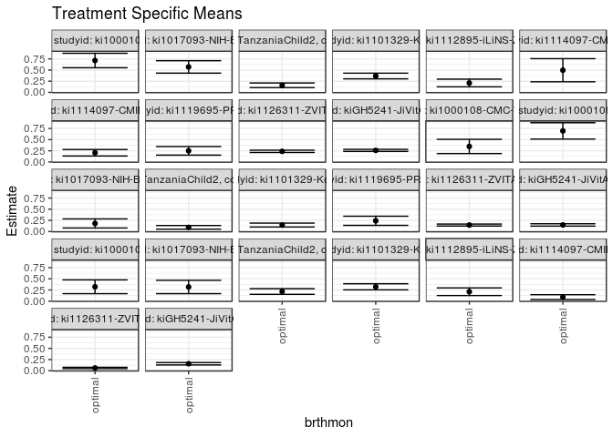

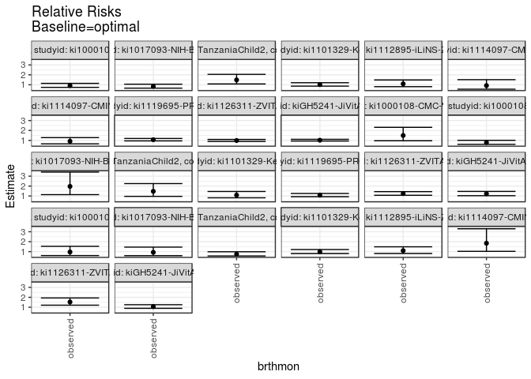

## Results Table

### Parameter: TSM

| agecat | studyid | country | intervention_level | baseline_level | estimate | ci_lower | ci_upper |
| --- | --- | --- | --- | --- | --- | --- | --- |
| 0-24 months | ki1000108-IRC | INDIA | optimal | NA | 0.7134076 | 0.5515346 | 0.8752805 |
| 0-24 months | ki1017093-NIH-Birth | BANGLADESH | optimal | NA | 0.5700574 | 0.4306064 | 0.7095084 |
| 0-24 months | ki1066203-TanzaniaChild2 | TANZANIA, UNITED REPUBLIC OF | optimal | NA | 0.1586019 | 0.1064192 | 0.2107845 |
| 0-24 months | ki1101329-Keneba | GAMBIA | optimal | NA | 0.3667151 | 0.3029418 | 0.4304883 |
| 0-24 months | ki1112895-iLiNS-Zinc | BURKINA FASO | optimal | NA | 0.2105093 | 0.1245956 | 0.2964230 |
| 0-24 months | ki1114097-CMIN | BANGLADESH | optimal | NA | 0.4963565 | 0.2375814 | 0.7551315 |
| 0-24 months | ki1114097-CMIN | GUINEA-BISSAU | optimal | NA | 0.2063264 | 0.1338318 | 0.2788210 |
| 0-24 months | ki1119695-PROBIT | BELARUS | optimal | NA | 0.2491507 | 0.1530341 | 0.3452674 |
| 0-24 months | ki1126311-ZVITAMBO | ZIMBABWE | optimal | NA | 0.2375720 | 0.2118162 | 0.2633277 |
| 0-24 months | kiGH5241-JiVitA-3 | BANGLADESH | optimal | NA | 0.2593228 | 0.2358121 | 0.2828335 |
| 0-6 months | ki1000108-CMC-V-BCS-2002 | INDIA | optimal | NA | 0.3474046 | 0.1883751 | 0.5064341 |
| 0-6 months | ki1000108-IRC | INDIA | optimal | NA | 0.6953070 | 0.5120272 | 0.8785867 |
| 0-6 months | ki1017093-NIH-Birth | BANGLADESH | optimal | NA | 0.1813420 | 0.0789932 | 0.2836907 |
| 0-6 months | ki1066203-TanzaniaChild2 | TANZANIA, UNITED REPUBLIC OF | optimal | NA | 0.0943765 | 0.0532048 | 0.1355481 |
| 0-6 months | ki1101329-Keneba | GAMBIA | optimal | NA | 0.1456617 | 0.1015790 | 0.1897444 |
| 0-6 months | ki1119695-PROBIT | BELARUS | optimal | NA | 0.2407825 | 0.1387871 | 0.3427780 |
| 0-6 months | ki1126311-ZVITAMBO | ZIMBABWE | optimal | NA | 0.1456666 | 0.1236506 | 0.1676826 |
| 0-6 months | kiGH5241-JiVitA-3 | BANGLADESH | optimal | NA | 0.1483986 | 0.1218302 | 0.1749669 |
| 6-24 months | ki1000108-IRC | INDIA | optimal | NA | 0.3212982 | 0.1667209 | 0.4758755 |
| 6-24 months | ki1017093-NIH-Birth | BANGLADESH | optimal | NA | 0.3167518 | 0.1679376 | 0.4655660 |
| 6-24 months | ki1066203-TanzaniaChild2 | TANZANIA, UNITED REPUBLIC OF | optimal | NA | 0.2156146 | 0.1520595 | 0.2791698 |
| 6-24 months | ki1101329-Keneba | GAMBIA | optimal | NA | 0.3211902 | 0.2529591 | 0.3894212 |
| 6-24 months | ki1112895-iLiNS-Zinc | BURKINA FASO | optimal | NA | 0.2105093 | 0.1245956 | 0.2964230 |
| 6-24 months | ki1114097-CMIN | GUINEA-BISSAU | optimal | NA | 0.0903704 | 0.0365589 | 0.1441818 |
| 6-24 months | ki1126311-ZVITAMBO | ZIMBABWE | optimal | NA | 0.0615562 | 0.0465731 | 0.0765392 |
| 6-24 months | kiGH5241-JiVitA-3 | BANGLADESH | optimal | NA | 0.1560683 | 0.1291123 | 0.1830243 |

### Parameter: E(Y)

| agecat | studyid | country | intervention_level | baseline_level | estimate | ci_lower | ci_upper |
| --- | --- | --- | --- | --- | --- | --- | --- |
| 0-24 months | ki1000108-IRC | INDIA | observed | NA | 0.6560976 | 0.6100625 | 0.7021326 |
| 0-24 months | ki1017093-NIH-Birth | BANGLADESH | observed | NA | 0.4775641 | 0.4383415 | 0.5167867 |
| 0-24 months | ki1066203-TanzaniaChild2 | TANZANIA, UNITED REPUBLIC OF | observed | NA | 0.2362270 | 0.2192156 | 0.2532385 |
| 0-24 months | ki1101329-Keneba | GAMBIA | observed | NA | 0.3741007 | 0.3565437 | 0.3916578 |
| 0-24 months | ki1112895-iLiNS-Zinc | BURKINA FASO | observed | NA | 0.2308657 | 0.1897291 | 0.2720024 |
| 0-24 months | ki1114097-CMIN | BANGLADESH | observed | NA | 0.4558824 | 0.3965849 | 0.5151798 |
| 0-24 months | ki1114097-CMIN | GUINEA-BISSAU | observed | NA | 0.1884539 | 0.1687026 | 0.2082051 |
| 0-24 months | ki1119695-PROBIT | BELARUS | observed | NA | 0.2655346 | 0.1719990 | 0.3590703 |
| 0-24 months | ki1126311-ZVITAMBO | ZIMBABWE | observed | NA | 0.2347371 | 0.2277008 | 0.2417734 |
| 0-24 months | kiGH5241-JiVitA-3 | BANGLADESH | observed | NA | 0.2643109 | 0.2552337 | 0.2733881 |
| 0-6 months | ki1000108-CMC-V-BCS-2002 | INDIA | observed | NA | 0.5190217 | 0.4679041 | 0.5701394 |
| 0-6 months | ki1000108-IRC | INDIA | observed | NA | 0.5439024 | 0.4956326 | 0.5921723 |
| 0-6 months | ki1017093-NIH-Birth | BANGLADESH | observed | NA | 0.3569132 | 0.3192325 | 0.3945938 |
| 0-6 months | ki1066203-TanzaniaChild2 | TANZANIA, UNITED REPUBLIC OF | observed | NA | 0.1389816 | 0.1251275 | 0.1528358 |
| 0-6 months | ki1101329-Keneba | GAMBIA | observed | NA | 0.1592121 | 0.1446830 | 0.1737413 |
| 0-6 months | ki1119695-PROBIT | BELARUS | observed | NA | 0.2599065 | 0.1654090 | 0.3544039 |
| 0-6 months | ki1126311-ZVITAMBO | ZIMBABWE | observed | NA | 0.1810500 | 0.1746363 | 0.1874638 |
| 0-6 months | kiGH5241-JiVitA-3 | BANGLADESH | observed | NA | 0.1823042 | 0.1743031 | 0.1903054 |
| 6-24 months | ki1000108-IRC | INDIA | observed | NA | 0.3097561 | 0.2649438 | 0.3545684 |
| 6-24 months | ki1017093-NIH-Birth | BANGLADESH | observed | NA | 0.2939002 | 0.2554778 | 0.3323226 |
| 6-24 months | ki1066203-TanzaniaChild2 | TANZANIA, UNITED REPUBLIC OF | observed | NA | 0.1605550 | 0.1445335 | 0.1765765 |
| 6-24 months | ki1101329-Keneba | GAMBIA | observed | NA | 0.3170197 | 0.2995873 | 0.3344522 |
| 6-24 months | ki1112895-iLiNS-Zinc | BURKINA FASO | observed | NA | 0.2308657 | 0.1897291 | 0.2720024 |
| 6-24 months | ki1114097-CMIN | GUINEA-BISSAU | observed | NA | 0.1666667 | 0.1476863 | 0.1856470 |
| 6-24 months | ki1126311-ZVITAMBO | ZIMBABWE | observed | NA | 0.0939779 | 0.0884472 | 0.0995086 |
| 6-24 months | kiGH5241-JiVitA-3 | BANGLADESH | observed | NA | 0.1651666 | 0.1559963 | 0.1743368 |

### Parameter: RR

| agecat | studyid | country | intervention_level | baseline_level | estimate | ci_lower | ci_upper |
| --- | --- | --- | --- | --- | --- | --- | --- |
| 0-24 months | ki1000108-IRC | INDIA | observed | optimal | 0.9196672 | 0.7407537 | 1.1417935 |
| 0-24 months | ki1017093-NIH-Birth | BANGLADESH | observed | optimal | 0.8377474 | 0.6620623 | 1.0600524 |
| 0-24 months | ki1066203-TanzaniaChild2 | TANZANIA, UNITED REPUBLIC OF | observed | optimal | 1.4894343 | 1.0822378 | 2.0498403 |
| 0-24 months | ki1101329-Keneba | GAMBIA | observed | optimal | 1.0201400 | 0.8627854 | 1.2061929 |
| 0-24 months | ki1112895-iLiNS-Zinc | BURKINA FASO | observed | optimal | 1.0967008 | 0.8096715 | 1.4854823 |
| 0-24 months | ki1114097-CMIN | BANGLADESH | observed | optimal | 0.9184576 | 0.5569343 | 1.5146567 |
| 0-24 months | ki1114097-CMIN | GUINEA-BISSAU | observed | optimal | 0.9133775 | 0.6523095 | 1.2789305 |
| 0-24 months | ki1119695-PROBIT | BELARUS | observed | optimal | 1.0657590 | 0.9509006 | 1.1944910 |
| 0-24 months | ki1126311-ZVITAMBO | ZIMBABWE | observed | optimal | 0.9880672 | 0.8904101 | 1.0964350 |
| 0-24 months | kiGH5241-JiVitA-3 | BANGLADESH | observed | optimal | 1.0192351 | 0.9355999 | 1.1103467 |
| 0-6 months | ki1000108-CMC-V-BCS-2002 | INDIA | observed | optimal | 1.4939979 | 0.9644239 | 2.3143656 |
| 0-6 months | ki1000108-IRC | INDIA | observed | optimal | 0.7822479 | 0.6064270 | 1.0090444 |
| 0-6 months | ki1017093-NIH-Birth | BANGLADESH | observed | optimal | 1.9681775 | 1.1368777 | 3.4073346 |
| 0-6 months | ki1066203-TanzaniaChild2 | TANZANIA, UNITED REPUBLIC OF | observed | optimal | 1.4726298 | 0.9633636 | 2.2511109 |
| 0-6 months | ki1101329-Keneba | GAMBIA | observed | optimal | 1.0930270 | 0.8205774 | 1.4559357 |
| 0-6 months | ki1119695-PROBIT | BELARUS | observed | optimal | 1.0794241 | 0.9285786 | 1.2547741 |
| 0-6 months | ki1126311-ZVITAMBO | ZIMBABWE | observed | optimal | 1.2429073 | 1.0734779 | 1.4390781 |
| 0-6 months | kiGH5241-JiVitA-3 | BANGLADESH | observed | optimal | 1.2284769 | 1.0332076 | 1.4606508 |
| 6-24 months | ki1000108-IRC | INDIA | observed | optimal | 0.9640765 | 0.6056155 | 1.5347089 |
| 6-24 months | ki1017093-NIH-Birth | BANGLADESH | observed | optimal | 0.9278564 | 0.5918863 | 1.4545317 |
| 6-24 months | ki1066203-TanzaniaChild2 | TANZANIA, UNITED REPUBLIC OF | observed | optimal | 0.7446387 | 0.5613457 | 0.9877813 |
| 6-24 months | ki1101329-Keneba | GAMBIA | observed | optimal | 0.9870157 | 0.8042510 | 1.2113133 |
| 6-24 months | ki1112895-iLiNS-Zinc | BURKINA FASO | observed | optimal | 1.0967008 | 0.8096715 | 1.4854823 |
| 6-24 months | ki1114097-CMIN | GUINEA-BISSAU | observed | optimal | 1.8442626 | 1.0302419 | 3.3014623 |
| 6-24 months | ki1126311-ZVITAMBO | ZIMBABWE | observed | optimal | 1.5267023 | 1.2061951 | 1.9323739 |
| 6-24 months | kiGH5241-JiVitA-3 | BANGLADESH | observed | optimal | 1.0582967 | 0.8922654 | 1.2552228 |

### Parameter: PAR

| agecat | studyid | country | intervention_level | baseline_level | estimate | ci_lower | ci_upper |
| --- | --- | --- | --- | --- | --- | --- | --- |
| 0-24 months | ki1000108-IRC | INDIA | optimal | NA | -0.0573100 | -0.2116714 | 0.0970513 |
| 0-24 months | ki1017093-NIH-Birth | BANGLADESH | optimal | NA | -0.0924933 | -0.2264239 | 0.0414373 |
| 0-24 months | ki1066203-TanzaniaChild2 | TANZANIA, UNITED REPUBLIC OF | optimal | NA | 0.0776252 | 0.0267953 | 0.1284551 |
| 0-24 months | ki1101329-Keneba | GAMBIA | optimal | NA | 0.0073856 | -0.0540514 | 0.0688227 |
| 0-24 months | ki1112895-iLiNS-Zinc | BURKINA FASO | optimal | NA | 0.0203564 | -0.0421741 | 0.0828870 |
| 0-24 months | ki1114097-CMIN | BANGLADESH | optimal | NA | -0.0404741 | -0.2890190 | 0.2080707 |
| 0-24 months | ki1114097-CMIN | GUINEA-BISSAU | optimal | NA | -0.0178725 | -0.0873309 | 0.0515858 |
| 0-24 months | ki1119695-PROBIT | BELARUS | optimal | NA | 0.0163839 | -0.0117693 | 0.0445371 |
| 0-24 months | ki1126311-ZVITAMBO | ZIMBABWE | optimal | NA | -0.0028349 | -0.0275592 | 0.0218894 |
| 0-24 months | kiGH5241-JiVitA-3 | BANGLADESH | optimal | NA | 0.0049881 | -0.0172242 | 0.0272004 |
| 0-6 months | ki1000108-CMC-V-BCS-2002 | INDIA | optimal | NA | 0.1716171 | 0.0202515 | 0.3229828 |
| 0-6 months | ki1000108-IRC | INDIA | optimal | NA | -0.1514045 | -0.3279763 | 0.0251672 |
| 0-6 months | ki1017093-NIH-Birth | BANGLADESH | optimal | NA | 0.1755712 | 0.0753136 | 0.2758288 |
| 0-6 months | ki1066203-TanzaniaChild2 | TANZANIA, UNITED REPUBLIC OF | optimal | NA | 0.0446051 | 0.0043229 | 0.0848874 |
| 0-6 months | ki1101329-Keneba | GAMBIA | optimal | NA | 0.0135505 | -0.0282036 | 0.0553045 |
| 0-6 months | ki1119695-PROBIT | BELARUS | optimal | NA | 0.0191239 | -0.0162144 | 0.0544623 |
| 0-6 months | ki1126311-ZVITAMBO | ZIMBABWE | optimal | NA | 0.0353835 | 0.0140128 | 0.0567542 |
| 0-6 months | kiGH5241-JiVitA-3 | BANGLADESH | optimal | NA | 0.0339056 | 0.0081895 | 0.0596218 |
| 6-24 months | ki1000108-IRC | INDIA | optimal | NA | -0.0115421 | -0.1608613 | 0.1377770 |
| 6-24 months | ki1017093-NIH-Birth | BANGLADESH | optimal | NA | -0.0228516 | -0.1653215 | 0.1196182 |
| 6-24 months | ki1066203-TanzaniaChild2 | TANZANIA, UNITED REPUBLIC OF | optimal | NA | -0.0550596 | -0.1159480 | 0.0058287 |
| 6-24 months | ki1101329-Keneba | GAMBIA | optimal | NA | -0.0041704 | -0.0699441 | 0.0616033 |
| 6-24 months | ki1112895-iLiNS-Zinc | BURKINA FASO | optimal | NA | 0.0203564 | -0.0421741 | 0.0828870 |
| 6-24 months | ki1114097-CMIN | GUINEA-BISSAU | optimal | NA | 0.0762963 | 0.0231269 | 0.1294657 |
| 6-24 months | ki1126311-ZVITAMBO | ZIMBABWE | optimal | NA | 0.0324218 | 0.0178093 | 0.0470342 |
| 6-24 months | kiGH5241-JiVitA-3 | BANGLADESH | optimal | NA | 0.0090983 | -0.0176031 | 0.0357996 |

### Parameter: PAF

| agecat | studyid | country | intervention_level | baseline_level | estimate | ci_lower | ci_upper |
| --- | --- | --- | --- | --- | --- | --- | --- |
| 0-24 months | ki1000108-IRC | INDIA | optimal | NA | -0.0873499 | -0.3499764 | 0.1241849 |
| 0-24 months | ki1017093-NIH-Birth | BANGLADESH | optimal | NA | -0.1936772 | -0.5104319 | 0.0566504 |
| 0-24 months | ki1066203-TanzaniaChild2 | TANZANIA, UNITED REPUBLIC OF | optimal | NA | 0.3286042 | 0.0759886 | 0.5121571 |
| 0-24 months | ki1101329-Keneba | GAMBIA | optimal | NA | 0.0197424 | -0.1590368 | 0.1709452 |
| 0-24 months | ki1112895-iLiNS-Zinc | BURKINA FASO | optimal | NA | 0.0881743 | -0.2350688 | 0.3268180 |
| 0-24 months | ki1114097-CMIN | BANGLADESH | optimal | NA | -0.0887819 | -0.7955439 | 0.3397844 |
| 0-24 months | ki1114097-CMIN | GUINEA-BISSAU | optimal | NA | -0.0948376 | -0.5330147 | 0.2180967 |
| 0-24 months | ki1119695-PROBIT | BELARUS | optimal | NA | 0.0617016 | -0.0516346 | 0.1628233 |
| 0-24 months | ki1126311-ZVITAMBO | ZIMBABWE | optimal | NA | -0.0120769 | -0.1230780 | 0.0879533 |
| 0-24 months | kiGH5241-JiVitA-3 | BANGLADESH | optimal | NA | 0.0188721 | -0.0688330 | 0.0993804 |
| 0-6 months | ki1000108-CMC-V-BCS-2002 | INDIA | optimal | NA | 0.3306550 | -0.0368884 | 0.5679162 |
| 0-6 months | ki1000108-IRC | INDIA | optimal | NA | -0.2783671 | -0.6490031 | 0.0089634 |
| 0-6 months | ki1017093-NIH-Birth | BANGLADESH | optimal | NA | 0.4919157 | 0.1203979 | 0.7065155 |
| 0-6 months | ki1066203-TanzaniaChild2 | TANZANIA, UNITED REPUBLIC OF | optimal | NA | 0.3209427 | -0.0380296 | 0.5557749 |
| 0-6 months | ki1101329-Keneba | GAMBIA | optimal | NA | 0.0851095 | -0.2186541 | 0.3131565 |
| 0-6 months | ki1119695-PROBIT | BELARUS | optimal | NA | 0.0735801 | -0.0769147 | 0.2030438 |
| 0-6 months | ki1126311-ZVITAMBO | ZIMBABWE | optimal | NA | 0.1954348 | 0.0684485 | 0.3051107 |
| 0-6 months | kiGH5241-JiVitA-3 | BANGLADESH | optimal | NA | 0.1859839 | 0.0321403 | 0.3153737 |
| 6-24 months | ki1000108-IRC | INDIA | optimal | NA | -0.0372620 | -0.6512126 | 0.3484106 |
| 6-24 months | ki1017093-NIH-Birth | BANGLADESH | optimal | NA | -0.0777530 | -0.6895136 | 0.3124935 |
| 6-24 months | ki1066203-TanzaniaChild2 | TANZANIA, UNITED REPUBLIC OF | optimal | NA | -0.3429332 | -0.7814336 | -0.0123698 |
| 6-24 months | ki1101329-Keneba | GAMBIA | optimal | NA | -0.0131551 | -0.2433929 | 0.1744498 |
| 6-24 months | ki1112895-iLiNS-Zinc | BURKINA FASO | optimal | NA | 0.0881743 | -0.2350688 | 0.3268180 |
| 6-24 months | ki1114097-CMIN | GUINEA-BISSAU | optimal | NA | 0.4577779 | 0.0293542 | 0.6971039 |
| 6-24 months | ki1126311-ZVITAMBO | ZIMBABWE | optimal | NA | 0.3449935 | 0.1709468 | 0.4825018 |
| 6-24 months | kiGH5241-JiVitA-3 | BANGLADESH | optimal | NA | 0.0550854 | -0.1207427 | 0.2033287 |